# 전자산업데이터분석 기말 PROJECT

## 데이터 불러오기

```python
!pip install -U pandas_profiling
!pip install markupsafe==2.0.1
```

```
  Attempting uninstall: markupsafe
    Found existing installation: MarkupSafe 1.1.1
    Uninstalling MarkupSafe-1.1.1:
      Successfully uninstalled MarkupSafe-1.1.1
```

[output not shown]

```
  Attempting uninstall: markupsafe
    Found existing installation: MarkupSafe 2.1.1
    Uninstalling MarkupSafe-2.1.1:
      Successfully uninstalled MarkupSafe-2.1.1
```

[output not shown]

```python
%matplotlib inline
import matplotlib.pyplot as plt
import pandas as pd
import numpy as np
import pandas_profiling
import seaborn as sns
import random

sns.set()
```

```python
plt.rcParams['font.family'] = ['NanumBarunGothic', 'Malgun Gothic', 'AppleGothic']  # 한글 출력을 위한 글꼴 설정
plt.rcParams['axes.unicode_minus'] = False    # 문자 - (마이너스) 정상 출력을 위한 코드
```

```python
ElectroWorld_df = pd.read_csv('C:/Users/jinje/1학기_전자산업데이터분석/ElectroWorld_Data_processed.csv', encoding='cp949')
city_df = pd.read_csv('C:/Users/jinje/1학기_전자산업데이터분석/City_Information.csv', encoding='cp949')
```

```python
ElectroWorld_df.head(3)
```

|  | record_id | order_id | order_date | order_priority | unit_price | order_quantity | sales | order_status | discount | profit | ... | ship_cost | ship_date | customer_segment | customer_name | city | product_category | product_sub_category | product_name | product_container | product_base_margin |
| --- | --- | --- | --- | --- | --- | --- | --- | --- | --- | --- | --- | --- | --- | --- | --- | --- | --- | --- | --- | --- | --- |
| 0 | 0 | 41660 | 2018.10.3 | medium | 14.97 | 25 | 362.5256 | returned | 0.07 | -68.4888 | ... | 7.519 | 2018.10.4 | Corporate | Bauline Chand | Norman | Office Supplies | Storage & Organization | Pizazz Global Quick File™ | Small Box | 0.57 |
| 1 | 1 | 28850 | 2019.9.4 | medium | 49.34 | 48 | 2271.3756 | completed | 0.09 | 528.1112 | ... | 10.259 | 2019.9.6 | Small Business | Cynthia Arntzen | Spring Hill | Furniture | Office Furnishings | Electrix Fluorescent Magnifier Lamps & Weighte... | Large Box | 0.57 |
| 2 | 2 | 4513 | 2017.1.28 | critical | 55.99 | 47 | 2053.3846 | completed | 0.10 | 1040.4012 | ... | 1.259 | 2017.1.30 | Home Office | Susan Gilcrest | Gainesville | Technology | Telephones and Communication | Accessory32 | Small Pack | 0.35 |

3 rows × 21 columns

```python
ElectroWorld_df.set_index('city')
```

| city | record_id | order_id | order_date | order_priority | unit_price | order_quantity | sales | order_status | discount | profit | ship_mode | ship_cost | ship_date | customer_segment | customer_name | product_category | product_sub_category | product_name | product_container | product_base_margin |
| --- | --- | --- | --- | --- | --- | --- | --- | --- | --- | --- | --- | --- | --- | --- | --- | --- | --- | --- | --- | --- |
| Norman | 0 | 41660 | 2018.10.3 | medium | 14.97 | 25 | 362.5256 | returned | 0.07 | -68.4888 | Regular Air | 7.519 | 2018.10.4 | Corporate | Bauline Chand | Office Supplies | Storage & Organization | Pizazz Global Quick File™ | Small Box | 0.57 |
| Spring Hill | 1 | 28850 | 2019.9.4 | medium | 49.34 | 48 | 2271.3756 | completed | 0.09 | 528.1112 | Express Air | 10.259 | 2019.9.6 | Small Business | Cynthia Arntzen | Furniture | Office Furnishings | Electrix Fluorescent Magnifier Lamps & Weighte... | Large Box | 0.57 |
| Gainesville | 2 | 4513 | 2017.1.28 | critical | 55.99 | 47 | 2053.3846 | completed | 0.10 | 1040.4012 | Regular Air | 1.259 | 2017.1.30 | Home Office | Susan Gilcrest | Technology | Telephones and Communication | Accessory32 | Small Pack | 0.35 |
| West Valley City | 3 | 9214 | 2018.12.19 | high | 21.78 | 14 | 304.5256 | completed | 0.04 | 25.3412 | Regular Air | 5.949 | 2018.12.21 | Consumer | Georgia Rosenberg | Office Supplies | Appliances | Holmes HEPA Air Purifier | Medium Box | 0.50 |
| Birmingham | 4 | 14375 | 2017.12.8 | low | 550.98 | 24 | 10480.2776 | completed | 0.07 | 2271.6812 | Delivery Truck | 64.599 | 2017.12.10 | Home Office | Ionia NcGrath | Furniture | Tables | Chromcraft Bull-Nose Wood 48" x 96" Rectangula... | Jumbo Box | 0.66 |
| ... | ... | ... | ... | ... | ... | ... | ... | ... | ... | ... | ... | ... | ... | ... | ... | ... | ... | ... | ... | ... |
| Evans | 5495 | 51061 | 2017.1.16 | high | 17.78 | 26 | 430.3356 | completed | 0.08 | 85.4812 | Regular Air | 5.039 | 2017.1.18 | Home Office | Sam Craven | Furniture | Office Furnishings | Seth Thomas 13 1/2" Wall Clock | Small Box | 0.54 |
| Prairie Village | 5496 | 12458 | 2019.6.12 | medium | 3.14 | 41 | 133.2356 | completed | 0.00 | -59.9088 | Regular Air | 1.929 | 2019.6.13 | Home Office | Emily Grady | Office Supplies | Scissors, Rulers and Trimmers | Serrated Blade or Curved Handle Hand Letter Op... | Wrap Bag | 0.84 |
| Ogden | 5497 | 47317 | 2018.11.5 | NaN | 20.89 | 32 | 616.3956 | completed | 0.09 | 148.2812 | Regular Air | 1.999 | 2018.11.8 | Corporate | Vrian DeCherney | Technology | Computer Peripherals | IBM 80 Minute CD-R Spindle, 50/Pack | Small Pack | 0.48 |
| Carlsbad | 5498 | 32255 | 2019.11.14 | high | 115.99 | 10 | 1024.1706 | completed | 0.02 | -105.6978 | Regular Air | 5.999 | 2019.11.15 | Home Office | Risa Mazard | Technology | Telephones and Communication | 2160 | Small Box | 0.57 |
| West Des Moines | 5499 | 26432 | 2016.6.26 | critical | 100.98 | 46 | 4601.0256 | completed | 0.09 | -129.5288 | Delivery Truck | 35.849 | 2016.6.26 | Consumer | Seth Vernon | Furniture | Bookcases | Bush Westfield Collection Bookcases, Fully Ass... | Jumbo Box | 0.62 |

5500 rows × 20 columns

```python
city_df.head(3)
```

|  | city | state_name | region |
| --- | --- | --- | --- |
| 0 | Aberdeen | South Dakota | Central |
| 1 | Abilene | Texas | Central |
| 2 | Abington | MA | East |

```python
city_df.set_index('city')
```

| city | state_name | region |
| --- | --- | --- |
| Aberdeen | South Dakota | Central |
| Abilene | Texas | Central |
| Abington | MA | East |
| Addison | Illinois | Central |
| Adrian | Michigan | Central |
| ... | ... | ... |
| York | Pennsylvania | East |
| Youngstown | Ohio | East |
| Yuba City | California | West |
| Yucaipa | California | West |
| Yuma | Arizona | West |

1468 rows × 2 columns

```python
EW_df = pd.merge(ElectroWorld_df, city_df, how='inner', on='city')
```

```python
EW_df.shape
```

```
(7149, 23)
```

```python
np.random.seed(5)
idx = np.random.permutation(np.arange(len(EW_df['record_id'])))
```

```python
EW_df = EW_df.iloc[idx].drop_duplicates(["record_id"])
```

```python
EW_df.shape
```

```
(5500, 23)
```

```python
EW_df.columns
```

```
Index(['record_id', 'order_id', 'order_date', 'order_priority', 'unit_price',
       'order_quantity', 'sales', 'order_status', 'discount', 'profit',
       'ship_mode', 'ship_cost', 'ship_date', 'customer_segment',
       'customer_name', 'city', 'product_category', 'product_sub_category',
       'product_name', 'product_container', 'product_base_margin',
       'state_name', 'region'],
      dtype='object')
```

```python
EW_df.info()
```

```
<class 'pandas.core.frame.DataFrame'>
Int64Index: 5500 entries, 2203 to 2915
Data columns (total 23 columns):
 #   Column                Non-Null Count  Dtype
---  ------                --------------  -----
 0   record_id             5500 non-null   int64
 1   order_id              5500 non-null   int64
 2   order_date            5500 non-null   object
 3   order_priority        3937 non-null   object
 4   unit_price            5500 non-null   float64
 5   order_quantity        5500 non-null   int64
 6   sales                 5500 non-null   float64
 7   order_status          5500 non-null   object
 8   discount              4704 non-null   float64
 9   profit                5500 non-null   float64
 10  ship_mode             5500 non-null   object
 11  ship_cost             5500 non-null   float64
 12  ship_date             5500 non-null   object
 13  customer_segment      5500 non-null   object
 14  customer_name         5500 non-null   object
 15  city                  5500 non-null   object
 16  product_category      5500 non-null   object
 17  product_sub_category  5500 non-null   object
 18  product_name          5500 non-null   object
 19  product_container     5500 non-null   object
 20  product_base_margin   5456 non-null   float64
 21  state_name            5500 non-null   object
 22  region                5500 non-null   object
dtypes: float64(6), int64(3), object(14)
memory usage: 1.0+ MB
```

```python
EW_df.describe()
```

|  | record_id | order_id | unit_price | order_quantity | sales | discount | profit | ship_cost | product_base_margin |
| --- | --- | --- | --- | --- | --- | --- | --- | --- | --- |
| count | 5500.000000 | 5500.000000 | 5500.000000 | 5500.000000 | 5500.000000 | 4704.000000 | 5500.000000 | 5500.000000 | 5456.000000 |
| mean | 2749.500000 | 27699.999273 | 91.016335 | 25.602364 | 1833.011469 | 0.049643 | 199.665512 | 12.917522 | 0.514569 |
| std | 1587.857571 | 15875.967416 | 293.813688 | 14.484494 | 3767.616880 | 0.031868 | 1242.797572 | 17.276147 | 0.135093 |
| min | 0.000000 | 17.000000 | 1.140000 | 1.000000 | 2.245600 | 0.000000 | -14140.700400 | 0.499000 | 0.350000 |
| 25% | 1374.750000 | 13913.000000 | 6.480000 | 13.000000 | 148.910600 | 0.020000 | -83.186175 | 3.309000 | 0.380000 |
| 50% | 2749.500000 | 28094.000000 | 21.980000 | 26.000000 | 461.080600 | 0.050000 | -0.363800 | 6.144000 | 0.535000 |
| 75% | 4124.250000 | 41412.000000 | 90.970000 | 38.000000 | 1739.080100 | 0.080000 | 168.085950 | 13.999000 | 0.590000 |
| max | 5499.000000 | 55011.000000 | 6783.020000 | 50.000000 | 89061.055600 | 0.210000 | 27220.691200 | 164.739000 | 0.850000 |

컬럼별 unique한 갯수를 세어 중복 여부를 체크합니다.

```python
print(EW_df.shape)
for cn in EW_df.columns:
    print(f"{cn} : {EW_df[cn].unique().shape[0]}")
```

```
(5500, 23)
record_id : 5500
order_id : 3706
order_date : 1329
order_priority : 5
unit_price : 731
order_quantity : 50
sales : 5396
order_status : 2
discount : 15
profit : 5306
ship_mode : 3
ship_cost : 632
ship_date : 1411
customer_segment : 4
customer_name : 782
city : 1296
product_category : 3
product_sub_category : 17
product_name : 1223
product_container : 7
product_base_margin : 52
state_name : 48
region : 4
```

## 결측치 처리

`ship_mode`, `customer_segment`, `product_container`의 경우 엑셀을 통해 결측치를 처리합니다.

- `ship_mode` : `product name`, `production container`, `order_quantity`, `city`를 기준으로 일치하는 값으로 결측치 값 대체
- `customer_segment` : `customer name`와 `city`를 기준으로 일치하는 값으로 우선적으로 결측치를 채웠으며, `order_quantity`와 `product_sub_categoy` `product_name`를 참고하여 모든 결측치 값 대체
- `product_container` : `product_category`, `production_sub_category`, `product name`을 기준으로 일치하는 값으로 결측치 값 대체

```python
EW_df.isnull().sum()
```

```
record_id                  0
order_id                   0
order_date                 0
order_priority          1563
unit_price                 0
order_quantity             0
sales                      0
order_status               0
discount                 796
profit                     0
ship_mode                  0
ship_cost                  0
ship_date                  0
customer_segment           0
customer_name              0
city                       0
product_category           0
product_sub_category       0
product_name               0
product_container          0
product_base_margin       44
state_name                 0
region                     0
dtype: int64
```

### `order_priority` 결측치 처리

- random 함수를 사용하여 결측치를 임의로 배정합니다.

```python
EW_df[EW_df.order_priority.isna()].head(5)
```

|  | record_id | order_id | order_date | order_priority | unit_price | order_quantity | sales | order_status | discount | profit | ... | customer_segment | customer_name | city | product_category | product_sub_category | product_name | product_container | product_base_margin | state_name | region |
| --- | --- | --- | --- | --- | --- | --- | --- | --- | --- | --- | --- | --- | --- | --- | --- | --- | --- | --- | --- | --- | --- |
| 2203 | 322 | 4427 | 2016.10.27 | NaN | 5.38 | 31 | 181.1756 | completed | 0.06 | -59.8793 | ... | Home Office | Cathy Armstrong | Pueblo West | Office Supplies | Binders and Binder Accessories | Acco PRESSTEX Data Binder with Storage Hooks, ... | Small Box | 0.36 | Colorado | West |
| 1128 | 492 | 48983 | 2017.10.27 | NaN | 232.58 | 39 | 9081.9856 | completed | 0.02 | 2485.5412 | ... | Corporate | Alejandro Grove | Cincinnati | Office Supplies | Appliances | Hoover Commercial Lightweight Upright Vacuum w... | Small Box | 0.59 | Ohio | East |
| 7147 | 5434 | 2602 | 2019.9.5 | NaN | 399.98 | 37 | 14383.8356 | completed | 0.01 | 5050.1012 | ... | Corporate | Varry Franz | West Mifflin | Technology | Office Machines | Okidata ML320 Series Turbo Dot Matrix Printers | Jumbo Box | 0.56 | Pennsylvania | East |
| 5576 | 2878 | 52604 | 2018.4.19 | NaN | 30.98 | 43 | 1243.8856 | completed | 0.10 | 22.7112 | ... | Small Business | Cynthia Delaney | Dundalk | Office Supplies | Pens & Art Supplies | Boston School Pro Electric Pencil Sharpener, 1670 | Small Pack | 0.58 | Maryland | East |
| 5540 | 3160 | 37837 | 2018.3.6 | NaN | 6.75 | 40 | 291.6756 | returned | 0.01 | 54.4607 | ... | Small Business | Delfina Ratchford | Burbank | Office Supplies | Binders and Binder Accessories | Wilson Jones DublLock D-Ring Binders | Small Box | 0.35 | Illinois | Central |

5 rows × 23 columns

```python
EW_df["order_priority"].isna()
```

```
2203     True
1268    False
3634    False
5381    False
857     False
        ...
1982    False
2121    False
5520    False
3046    False
2915    False
Name: order_priority, Length: 5500, dtype: bool
```

```python
np.random.seed(3)
m = EW_df["order_priority"].isna()
EW_df.loc[m, 'order_priority'] = np.random.choice(EW_df.loc[~m, 'order_priority'], m.sum())
EW_df["order_priority"].value_counts()
```

```
low         1517
high        1408
critical    1329
medium      1246
Name: order_priority, dtype: int64
```

### `discount` 결측치 처리

- `product_sub_category` : product_sub_category별 평균값으로 결측치 처리
- `discount_mean` : discount 전체 값의 평균으로 결측치 처리
- `discount_zero` : '0'으로 결측치 처리
- 기존 `discount` 컬럼 삭제

```python
EW_df[EW_df.discount.isna()].head(3)
```

|  | record_id | order_id | order_date | order_priority | unit_price | order_quantity | sales | order_status | discount | profit | ... | customer_segment | customer_name | city | product_category | product_sub_category | product_name | product_container | product_base_margin | state_name | region |
| --- | --- | --- | --- | --- | --- | --- | --- | --- | --- | --- | --- | --- | --- | --- | --- | --- | --- | --- | --- | --- | --- |
| 2919 | 5142 | 31346 | 2017.11.28 | critical | 37.76 | 50 | 1844.2656 | completed | NaN | 47.58120 | ... | Small Business | Fred NcNath | Bangor | Office Supplies | Storage & Organization | Companion Letter/Legal File, Black | Small Box | 0.57 | Maine | East |
| 3740 | 3771 | 16029 | 2018.12.18 | critical | 15.23 | 35 | 539.2156 | completed | NaN | 11.65215 | ... | Corporate | Tracy Boddar | South Burlington | Furniture | Tables | Anderson Hickey Conga Table Tops & Accessories | Jumbo Box | 0.76 | Vermont | East |
| 1021 | 3090 | 17992 | 2016.12.19 | high | 90.48 | 27 | 2609.5356 | completed | NaN | 911.66120 | ... | Small Business | Nichael Nguyen | Watertown | Office Supplies | Envelopes | Tyvek Side-Opening Peel & Seel Expanding Envel... | Small Box | 0.40 | South Dakota | Central |

3 rows × 23 columns

```python
EW_df.city.value_counts()
```

```
Springfield     21
Auburn          19
Mount Vernon    18
Sanford         17
Lancaster       17
                ..
Nashua           1
Beverly          1
Clifton          1
Norton           1
Rocky Mount      1
Name: city, Length: 1296, dtype: int64
```

```python
EW_df.groupby('product_sub_category').discount.mean()
```

```
product_sub_category
Appliances                        0.052480
Binders and Binder Accessories    0.050833
Bookcases                         0.050000
Chairs & Chairmats                0.051227
Computer Peripherals              0.048019
Copiers and Fax                   0.049556
Envelopes                         0.047163
Labels                            0.049643
Office Furnishings                0.048270
Office Machines                   0.050622
Paper                             0.050280
Pens & Art Supplies               0.051610
Rubber Bands                      0.048523
Scissors, Rulers and Trimmers     0.046207
Storage & Organization            0.051118
Tables                            0.047074
Telephones and Communication      0.047800
Name: discount, dtype: float64
```

```python
EW_df.loc[:, "discount_sub_mean"] = EW_df.discount.fillna(EW_df.groupby('product_sub_category')['discount'].transform('mean'))
```

```python
EW_df.loc[:, "discount_mean"] = EW_df.discount.fillna(EW_df.discount.mean())
```

```python
EW_df.loc[:, "discount_zero"] = EW_df.discount.fillna(0)
```

```python
EW_df.drop(['discount'], axis=1, inplace = True)
```

```python
EW_df.info()
```

```
<class 'pandas.core.frame.DataFrame'>
Int64Index: 5500 entries, 2203 to 2915
Data columns (total 25 columns):
 #   Column                Non-Null Count  Dtype
---  ------                --------------  -----
 0   record_id             5500 non-null   int64
 1   order_id              5500 non-null   int64
 2   order_date            5500 non-null   object
 3   order_priority        5500 non-null   object
 4   unit_price            5500 non-null   float64
 5   order_quantity        5500 non-null   int64
 6   sales                 5500 non-null   float64
 7   order_status          5500 non-null   object
 8   profit                5500 non-null   float64
 9   ship_mode             5500 non-null   object
```

[output cut: 17 more lines]

### `product_base_margin` 결측치 처리

- `product_base_margin_sub_mean` : product_sub_category별 평균값으로 결측치 처리
- `product_base_margin_mean` : product_base_margin_mean 전체 값의 평균으로 결측치 처리
- 기존 `product_base_margin` 컬럼 삭제

```python
EW_df[EW_df.product_base_margin.isna()].head(3)
```

|  | record_id | order_id | order_date | order_priority | unit_price | order_quantity | sales | order_status | profit | ship_mode | ... | product_category | product_sub_category | product_name | product_container | product_base_margin | state_name | region | discount_sub_mean | discount_mean | discount_zero |
| --- | --- | --- | --- | --- | --- | --- | --- | --- | --- | --- | --- | --- | --- | --- | --- | --- | --- | --- | --- | --- | --- |
| 5273 | 1134 | 47899 | 2016.10.18 | critical | 276.20 | 25 | 6685.0556 | completed | 1653.6012 | Regular Air | ... | Furniture | Chairs & Chairmats | SAFCO Arco Folding Chair | Large Box | NaN | Georgia | South | 0.09 | 0.09 | 0.09 |
| 5760 | 4860 | 28095 | 2018.4.4 | low | 113.64 | 20 | 2227.3456 | completed | -609.0888 | Regular Air | ... | Office Supplies | Storage & Organization | SAFCO Boltless Steel Shelving | Large Box | NaN | Oklahoma | Central | 0.09 | 0.09 | 0.09 |
| 848 | 4935 | 13744 | 2016.11.9 | low | 95.99 | 10 | 994.0456 | completed | -335.0588 | Regular Air | ... | Office Supplies | Storage & Organization | Safco Industrial Wire Shelving | Large Box | NaN | Ohio | East | 0.03 | 0.03 | 0.03 |

3 rows × 25 columns

```python
EW_df.product_base_margin.describe()
```

```
count    5456.000000
mean        0.514569
std         0.135093
min         0.350000
25%         0.380000
50%         0.535000
75%         0.590000
max         0.850000
Name: product_base_margin, dtype: float64
```

```python
EW_df.groupby('product_sub_category').product_base_margin.mean()
```

```
product_sub_category
Appliances                        0.556533
Binders and Binder Accessories    0.374269
Bookcases                         0.658031
Chairs & Chairmats                0.630212
Computer Peripherals              0.603025
Copiers and Fax                   0.419123
Envelopes                         0.374785
Labels                            0.376995
Office Furnishings                0.528910
Office Machines                   0.443604
Paper                             0.374182
Pens & Art Supplies               0.533811
Rubber Bands                      0.556699
Scissors, Rulers and Trimmers     0.633196
Storage & Organization            0.660357
Tables                            0.696000
Telephones and Communication      0.579915
Name: product_base_margin, dtype: float64
```

```python
EW_df.loc[:, "product_base_margin_sub_mean"] = EW_df.product_base_margin.fillna(EW_df.groupby('product_sub_category')['product_base_margin'].transform('mean'))
```

```python
EW_df.loc[:, "product_base_margin_mean"] = EW_df.product_base_margin.fillna(EW_df.product_base_margin.mean())
```

```python
EW_df.drop(['product_base_margin'], axis=1, inplace = True)
```

```python
EW_df.info()
```

```
<class 'pandas.core.frame.DataFrame'>
Int64Index: 5500 entries, 2203 to 2915
Data columns (total 26 columns):
 #   Column                        Non-Null Count  Dtype
---  ------                        --------------  -----
 0   record_id                     5500 non-null   int64
 1   order_id                      5500 non-null   int64
 2   order_date                    5500 non-null   object
 3   order_priority                5500 non-null   object
 4   unit_price                    5500 non-null   float64
 5   order_quantity                5500 non-null   int64
 6   sales                         5500 non-null   float64
 7   order_status                  5500 non-null   object
 8   profit                        5500 non-null   float64
 9   ship_mode                     5500 non-null   object
```

[output cut: 18 more lines]

## 파생변수 생성

### `new_sales` 파생변수 생성

- 기존 `sales` 값의 산정방식(개당가격 *수량, 개당가격* 수량 *할인율 등으로 sales 값이 나오지 않음)에 차이가 있어 \ (`unit_price`* `order_quantity`) * (1 - `discount_mean`) 산식으로 추가 변수 생성

```python
EW_df.loc[:,"new_sales"] = (EW_df.unit_price * EW_df.order_quantity) * (1 -  EW_df.discount_mean)
```

```python
EW_df.new_sales.describe()
```

```
count     5500.000000
mean      1813.643988
std       3725.872654
min          1.465200
25%        137.100254
50%        436.586600
75%       1721.476125
max      88179.260000
Name: new_sales, dtype: float64
```

### `orderdate` 파생변수 생성

- `orderdate` 날짜형태로 바꾼 후, \ 연월, 년, 월, 요일, 분기의 추가 변수 생성

```python
EW_df.loc[:,"order_date"] = pd.to_datetime(EW_df.order_date)
```

```python
EW_df.order_date
```

```
2203   2016-10-27
1268   2018-09-08
3634   2019-11-22
5381   2017-11-28
857    2016-05-21
          ...
1982   2019-08-17
2121   2016-05-26
5520   2019-01-10
3046   2017-09-06
2915   2018-02-22
Name: order_date, Length: 5500, dtype: datetime64[ns]
```

#### 연월

```python
EW_df.order_date.dt.year * 100 + EW_df.order_date.dt.month
```

```
2203    201610
1268    201809
3634    201911
5381    201711
857     201605
         ...
1982    201908
2121    201605
5520    201901
3046    201709
2915    201802
Name: order_date, Length: 5500, dtype: int64
```

```python
EW_df.loc[:,"order_yearmonth"] = EW_df.order_date.dt.year * 100 + EW_df.order_date.dt.month
EW_df.order_yearmonth
```

```
2203    201610
1268    201809
3634    201911
5381    201711
857     201605
         ...
1982    201908
2121    201605
5520    201901
3046    201709
2915    201802
Name: order_yearmonth, Length: 5500, dtype: int64
```

#### 년

```python
EW_df.order_date.dt.year
```

```
2203    2016
1268    2018
3634    2019
5381    2017
857     2016
        ...
1982    2019
2121    2016
5520    2019
3046    2017
2915    2018
Name: order_date, Length: 5500, dtype: int64
```

```python
EW_df.loc[:,"order_year"] = EW_df.order_date.dt.year
EW_df.order_year
```

```
2203    2016
1268    2018
3634    2019
5381    2017
857     2016
        ...
1982    2019
2121    2016
5520    2019
3046    2017
2915    2018
Name: order_year, Length: 5500, dtype: int64
```

#### 월

```python
EW_df.order_date.dt.month
```

```
2203    10
1268     9
3634    11
5381    11
857      5
        ..
1982     8
2121     5
5520     1
3046     9
2915     2
Name: order_date, Length: 5500, dtype: int64
```

```python
EW_df.loc[:,"order_month"] = EW_df.order_date.dt.month
EW_df.order_month
```

```
2203    10
1268     9
3634    11
5381    11
857      5
        ..
1982     8
2121     5
5520     1
3046     9
2915     2
Name: order_month, Length: 5500, dtype: int64
```

#### 요일

```python
EW_df.order_date.dt.day_of_week
```

```
2203    3
1268    5
3634    4
5381    1
857     5
       ..
1982    5
2121    3
5520    3
3046    2
2915    3
Name: order_date, Length: 5500, dtype: int64
```

```python
EW_df.loc[:,"order_day"] = EW_df.order_date.dt.day_of_week
EW_df.order_day
```

```
2203    3
1268    5
3634    4
5381    1
857     5
       ..
1982    5
2121    3
5520    3
3046    2
2915    3
Name: order_day, Length: 5500, dtype: int64
```

#### 분기

```python
map_dictionary = {1:1,2:1,3:1,4:2,5:2,6:2,7:3,8:3,9:3,10:4,11:4,12:4}
```

```python
EW_df.loc[:,"order_quarter"] = EW_df.loc[:,"order_month"].map(map_dictionary)
```

```python
EW_df.order_quarter.describe()
```

```
count    5500.000000
mean        2.510545
std         1.111397
min         1.000000
25%         2.000000
50%         3.000000
75%         3.000000
max         4.000000
Name: order_quarter, dtype: float64
```

### `ship_date` 파생변수 생성

- `ship_date` 날짜형태로 바꾼 후, \ 연월, 년, 월, 요일, 분기의 추가 변수 생성

```python
EW_df.loc[:,"ship_date"] = pd.to_datetime(EW_df.ship_date)
```

```python
EW_df.ship_date
```

```
2203   2016-10-29
1268   2018-09-09
3634   2019-11-23
5381   2017-11-29
857    2016-05-21
          ...
1982   2019-08-18
2121   2016-05-26
5520   2019-01-17
3046   2017-09-06
2915   2018-02-23
Name: ship_date, Length: 5500, dtype: datetime64[ns]
```

#### 연월

```python
EW_df.ship_date.dt.year * 100 + EW_df.ship_date.dt.month
```

```
2203    201610
1268    201809
3634    201911
5381    201711
857     201605
         ...
1982    201908
2121    201605
5520    201901
3046    201709
2915    201802
Name: ship_date, Length: 5500, dtype: int64
```

```python
EW_df.loc[:,"ship_yearmonth"] = EW_df.ship_date.dt.year * 100 + EW_df.ship_date.dt.month
EW_df.ship_yearmonth
```

```
2203    201610
1268    201809
3634    201911
5381    201711
857     201605
         ...
1982    201908
2121    201605
5520    201901
3046    201709
2915    201802
Name: ship_yearmonth, Length: 5500, dtype: int64
```

#### 년

```python
EW_df.ship_date.dt.year
```

```
2203    2016
1268    2018
3634    2019
5381    2017
857     2016
        ...
1982    2019
2121    2016
5520    2019
3046    2017
2915    2018
Name: ship_date, Length: 5500, dtype: int64
```

```python
EW_df.loc[:,"ship_year"] = EW_df.ship_date.dt.year
EW_df.ship_year
```

```
2203    2016
1268    2018
3634    2019
5381    2017
857     2016
        ...
1982    2019
2121    2016
5520    2019
3046    2017
2915    2018
Name: ship_year, Length: 5500, dtype: int64
```

#### 월

```python
EW_df.ship_date.dt.month
```

```
2203    10
1268     9
3634    11
5381    11
857      5
        ..
1982     8
2121     5
5520     1
3046     9
2915     2
Name: ship_date, Length: 5500, dtype: int64
```

```python
EW_df.loc[:,"ship_month"] = EW_df.ship_date.dt.month
EW_df.ship_month
```

```
2203    10
1268     9
3634    11
5381    11
857      5
        ..
1982     8
2121     5
5520     1
3046     9
2915     2
Name: ship_month, Length: 5500, dtype: int64
```

#### 요일

```python
EW_df.ship_date.dt.day_of_week
```

```
2203    5
1268    6
3634    5
5381    2
857     5
       ..
1982    6
2121    3
5520    3
3046    2
2915    4
Name: ship_date, Length: 5500, dtype: int64
```

```python
EW_df.loc[:,"ship_day"] = EW_df.ship_date.dt.day_of_week
EW_df.ship_day
```

```
2203    5
1268    6
3634    5
5381    2
857     5
       ..
1982    6
2121    3
5520    3
3046    2
2915    4
Name: ship_day, Length: 5500, dtype: int64
```

#### 분기

```python
map_dictionary = {1:1,2:1,3:1,4:2,5:2,6:2,7:3,8:3,9:3,10:4,11:4,12:4}
```

```python
EW_df.loc[:,"ship_quarter"] = EW_df.loc[:,"ship_month"].map(map_dictionary)
```

```python
EW_df.ship_quarter.describe()
```

```
count    5500.000000
mean        2.509455
std         1.111734
min         1.000000
25%         2.000000
50%         3.000000
75%         3.000000
max         4.000000
Name: ship_quarter, dtype: float64
```

## `lead_time` 추가 변수 생성

- `ship_date` - `oder_date` 하여 고객이 주문한 날짜로부터 배송되기까지 걸린 일자를 계산하여 새로운 컬럼(`lead_time`)에 할당

```python
# 주문에서 부터 배송되기까지 걸린 일자 계산
EW_df['lead_time'] = EW_df['ship_date'] - EW_df['order_date']
EW_df['lead_time'] = EW_df['lead_time'].dt.days
```

```python
EW_df.info()
```

```
<class 'pandas.core.frame.DataFrame'>
Int64Index: 5500 entries, 2203 to 2915
Data columns (total 38 columns):
 #   Column                        Non-Null Count  Dtype
---  ------                        --------------  -----
 0   record_id                     5500 non-null   int64
 1   order_id                      5500 non-null   int64
 2   order_date                    5500 non-null   datetime64[ns]
 3   order_priority                5500 non-null   object
 4   unit_price                    5500 non-null   float64
 5   order_quantity                5500 non-null   int64
 6   sales                         5500 non-null   float64
 7   order_status                  5500 non-null   object
 8   profit                        5500 non-null   float64
 9   ship_mode                     5500 non-null   object
```

[output cut: 30 more lines]

## Data Profiling

```python
#profile = EW_df.profile_report()
#profile
```

```python
# HTML로 저장
# profile.to_file(output_file="ElectroWorld.html")
```

# **[Project Prob A1]**

ElectroWorld 의 전반적인 비즈니스 경영 현황 점검을 수행하고자 합니다. \ 주어진 데이터를 이용하여 매출 및 수익성 등을 분석해보고, 개선점 or 제안점을 찾아보세요.

## 컬럼 나누어서 살펴보기

```python
# 데이터 컬럼 전반부
EW_df.iloc[:,0:12]
```

|  | record_id | order_id | order_date | order_priority | unit_price | order_quantity | sales | order_status | profit | ship_mode | ship_cost | ship_date |
| --- | --- | --- | --- | --- | --- | --- | --- | --- | --- | --- | --- | --- |
| 2203 | 322 | 4427 | 2016-10-27 | critical | 5.38 | 31 | 181.1756 | completed | -59.8793 | Express Air | 5.249 | 2016-10-29 |
| 1268 | 136 | 18692 | 2018-09-08 | high | 105.98 | 5 | 522.0656 | completed | 319.6412 | Regular Air | 13.999 | 2018-09-09 |
| 3634 | 2529 | 40664 | 2019-11-22 | medium | 299.05 | 21 | 6806.6656 | completed | 801.7212 | Delivery Truck | 87.019 | 2019-11-23 |
| 5381 | 1188 | 48394 | 2017-11-28 | high | 20.98 | 24 | 527.2556 | completed | 74.0107 | Regular Air | 8.839 | 2017-11-29 |
| 857 | 3377 | 13875 | 2016-05-21 | high | 2.61 | 40 | 104.3956 | completed | 38.4512 | Regular Air | 0.509 | 2016-05-21 |
| ... | ... | ... | ... | ... | ... | ... | ... | ... | ... | ... | ... | ... |
| 1982 | 1577 | 5093 | 2019-08-17 | medium | 29.99 | 36 | 1083.1956 | completed | 214.6112 | Express Air | 5.509 | 2019-08-18 |
| 2121 | 725 | 27560 | 2016-05-26 | medium | 35.94 | 28 | 1062.6956 | completed | 401.8012 | Regular Air | 6.669 | 2016-05-26 |
| 5520 | 4064 | 7010 | 2019-01-10 | low | 8.98 | 30 | 260.1256 | completed | 36.5412 | Regular Air | 4.199 | 2019-01-17 |
| 3046 | 4126 | 22979 | 2017-09-06 | medium | 12.98 | 11 | 141.0756 | completed | -5.0988 | Regular Air | 3.149 | 2017-09-06 |
| 2915 | 3538 | 42868 | 2018-02-22 | high | 3.98 | 2 | 11.1556 | completed | -5.5388 | Regular Air | 2.979 | 2018-02-23 |

5500 rows × 12 columns

```python
# 데이터 컬럼 중반부
EW_df.iloc[:,12:24]
```

|  | customer_segment | customer_name | city | product_category | product_sub_category | product_name | product_container | state_name | region | discount_sub_mean | discount_mean | discount_zero |
| --- | --- | --- | --- | --- | --- | --- | --- | --- | --- | --- | --- | --- |
| 2203 | Home Office | Cathy Armstrong | Pueblo West | Office Supplies | Binders and Binder Accessories | Acco PRESSTEX Data Binder with Storage Hooks, ... | Small Box | Colorado | West | 0.06 | 0.06 | 0.06 |
| 1268 | Consumer | Ivan Riston | Kingsville | Furniture | Office Furnishings | Tenex 46" x 60" Computer Anti-Static Chairmat,... | Medium Box | Texas | Central | 0.06 | 0.06 | 0.06 |
| 3634 | Corporate | Nichelle Ronsdale | Glendale Heights | Furniture | Chairs & Chairmats | Global Comet™ Stacking Armless Chair | Jumbo Drum | Illinois | Central | 0.00 | 0.00 | 0.00 |
| 5381 | Home Office | Eudokia Nartin | Leander | Office Supplies | Binders and Binder Accessories | Premium Transparent Presentation Covers by GBC | Small Box | Texas | Central | 0.01 | 0.01 | 0.01 |
| 857 | Corporate | Emily Grady | Spanish Fork | Office Supplies | Labels | Avery 494 | Small Box | Utah | West | 0.07 | 0.07 | 0.07 |
| ... | ... | ... | ... | ... | ... | ... | ... | ... | ... | ... | ... | ... |
| 1982 | Small Business | Christopher Nartinez | Thornton | Technology | Computer Peripherals | Logitech Cordless Access Keyboard | Small Box | Colorado | West | 0.03 | 0.03 | 0.03 |
| 2121 | Small Business | Aaron Smayling | Smithtown | Office Supplies | Envelopes | Tyvek Top-Opening Peel & Seel Envelopes, Gray | Small Box | New York | East | 0.01 | 0.01 | 0.01 |
| 5520 | Consumer | Nichelle Tran | Crofton | Furniture | Office Furnishings | Nu-Dell Float Frame 11 x 14 1/2 | Small Pack | Maryland | East | 0.05 | 0.05 | 0.05 |
| 3046 | Corporate | Sam Craven | Evans | Office Supplies | Scissors, Rulers and Trimmers | Acme 8" Straight Scissors | Small Pack | Georgia | South | 0.08 | 0.08 | 0.08 |
| 2915 | Small Business | Nichael Baige | Bangor | Office Supplies | Paper | Unpadded Memo Slips | Wrap Bag | Maine | East | 0.04 | 0.04 | 0.04 |

5500 rows × 12 columns

```python
# 데이터 컬럼 후반부
EW_df.iloc[:,24:]
```

|  | product_base_margin_sub_mean | product_base_margin_mean | new_sales | order_yearmonth | order_year | order_month | order_day | order_quarter | ship_yearmonth | ship_year | ship_month | ship_day | ship_quarter | lead_time |
| --- | --- | --- | --- | --- | --- | --- | --- | --- | --- | --- | --- | --- | --- | --- |
| 2203 | 0.36 | 0.36 | 156.7732 | 201610 | 2016 | 10 | 3 | 4 | 201610 | 2016 | 10 | 5 | 4 | 2 |
| 1268 | 0.65 | 0.65 | 498.1060 | 201809 | 2018 | 9 | 5 | 3 | 201809 | 2018 | 9 | 6 | 3 | 1 |
| 3634 | 0.57 | 0.57 | 6280.0500 | 201911 | 2019 | 11 | 4 | 4 | 201911 | 2019 | 11 | 5 | 4 | 1 |
| 5381 | 0.37 | 0.37 | 498.4848 | 201711 | 2017 | 11 | 1 | 4 | 201711 | 2017 | 11 | 2 | 4 | 1 |
| 857 | 0.39 | 0.39 | 97.0920 | 201605 | 2016 | 5 | 5 | 2 | 201605 | 2016 | 5 | 5 | 2 | 0 |
| ... | ... | ... | ... | ... | ... | ... | ... | ... | ... | ... | ... | ... | ... | ... |
| 1982 | 0.51 | 0.51 | 1047.2508 | 201908 | 2019 | 8 | 5 | 3 | 201908 | 2019 | 8 | 6 | 3 | 1 |
| 2121 | 0.40 | 0.40 | 996.2568 | 201605 | 2016 | 5 | 3 | 2 | 201605 | 2016 | 5 | 3 | 2 | 0 |
| 5520 | 0.43 | 0.43 | 255.9300 | 201901 | 2019 | 1 | 3 | 1 | 201901 | 2019 | 1 | 3 | 1 | 7 |
| 3046 | 0.60 | 0.60 | 131.3576 | 201709 | 2017 | 9 | 2 | 3 | 201709 | 2017 | 9 | 2 | 3 | 0 |
| 2915 | 0.35 | 0.35 | 7.6416 | 201802 | 2018 | 2 | 3 | 1 | 201802 | 2018 | 2 | 4 | 1 | 1 |

5500 rows × 14 columns

```python
EW_df.describe()
```

|  | record_id | order_id | unit_price | order_quantity | sales | profit | ship_cost | discount_sub_mean | discount_mean | discount_zero | ... | order_year | order_month | order_day | order_quarter | ship_yearmonth | ship_year | ship_month | ship_day | ship_quarter | lead_time |
| --- | --- | --- | --- | --- | --- | --- | --- | --- | --- | --- | --- | --- | --- | --- | --- | --- | --- | --- | --- | --- | --- |
| count | 5500.000000 | 5500.000000 | 5500.000000 | 5500.000000 | 5500.000000 | 5500.000000 | 5500.000000 | 5500.000000 | 5500.000000 | 5500.000000 | ... | 5500.000000 | 5500.000000 | 5500.000000 | 5500.000000 | 5500.000000 | 5500.000000 | 5500.000000 | 5500.000000 | 5500.000000 | 5500.000000 |
| mean | 2749.500000 | 27699.999273 | 91.016335 | 25.602364 | 1833.011469 | 199.665512 | 12.917522 | 0.049637 | 0.049643 | 0.042458 | ... | 2017.468364 | 6.521455 | 3.069091 | 2.510545 | 201753.971818 | 2017.474545 | 6.517273 | 3.060727 | 2.509455 | 2.086545 |
| std | 1587.857571 | 15875.967416 | 293.813688 | 14.484494 | 3767.616880 | 1242.797572 | 17.276147 | 0.029478 | 0.029471 | 0.034259 | ... | 1.124339 | 3.449015 | 1.993796 | 1.111397 | 112.279906 | 1.122068 | 3.446559 | 1.999896 | 1.111734 | 2.521658 |
| min | 0.000000 | 17.000000 | 1.140000 | 1.000000 | 2.245600 | -14140.700400 | 0.499000 | 0.000000 | 0.000000 | 0.000000 | ... | 2015.000000 | 1.000000 | 0.000000 | 1.000000 | 201601.000000 | 2016.000000 | 1.000000 | 0.000000 | 1.000000 | 0.000000 |
| 25% | 1374.750000 | 13913.000000 | 6.480000 | 13.000000 | 148.910600 | -83.186175 | 3.309000 | 0.030000 | 0.030000 | 0.010000 | ... | 2016.000000 | 4.000000 | 1.000000 | 2.000000 | 201612.000000 | 2016.000000 | 4.000000 | 1.000000 | 2.000000 | 1.000000 |
| 50% | 2749.500000 | 28094.000000 | 21.980000 | 26.000000 | 461.080600 | -0.363800 | 6.144000 | 0.050000 | 0.049643 | 0.040000 | ... | 2017.000000 | 7.000000 | 3.000000 | 3.000000 | 201712.000000 | 2017.000000 | 7.000000 | 3.000000 | 3.000000 | 2.000000 |
| 75% | 4124.250000 | 41412.000000 | 90.970000 | 38.000000 | 1739.080100 | 168.085950 | 13.999000 | 0.070000 | 0.070000 | 0.070000 | ... | 2018.000000 | 9.000000 | 5.000000 | 3.000000 | 201812.000000 | 2018.000000 | 9.000000 | 5.000000 | 3.000000 | 2.000000 |
| max | 5499.000000 | 55011.000000 | 6783.020000 | 50.000000 | 89061.055600 | 27220.691200 | 164.739000 | 0.210000 | 0.210000 | 0.210000 | ... | 2019.000000 | 12.000000 | 6.000000 | 4.000000 | 201912.000000 | 2019.000000 | 12.000000 | 6.000000 | 4.000000 | 92.000000 |

8 rows × 24 columns

.

```python
EW_df.columns
```

```
Index(['record_id', 'order_id', 'order_date', 'order_priority', 'unit_price',
       'order_quantity', 'sales', 'order_status', 'profit', 'ship_mode',
       'ship_cost', 'ship_date', 'customer_segment', 'customer_name', 'city',
       'product_category', 'product_sub_category', 'product_name',
       'product_container', 'state_name', 'region', 'discount_sub_mean',
       'discount_mean', 'discount_zero', 'product_base_margin_sub_mean',
       'product_base_margin_mean', 'new_sales', 'order_yearmonth',
       'order_year', 'order_month', 'order_day', 'order_quarter',
       'ship_yearmonth', 'ship_year', 'ship_month', 'ship_day', 'ship_quarter',
       'lead_time'],
      dtype='object')
```

```python
print(EW_df.shape)
for cn in EW_df.columns:
    print(f"{cn} : {EW_df[cn].unique().shape[0]}")
```

```
(5500, 38)
record_id : 5500
order_id : 3706
order_date : 1329
order_priority : 4
unit_price : 731
order_quantity : 50
sales : 5396
order_status : 2
profit : 5306
ship_mode : 3
ship_cost : 632
ship_date : 1411
customer_segment : 4
customer_name : 782
city : 1296
product_category : 3
product_sub_category : 17
product_name : 1223
product_container : 7
state_name : 48
region : 4
discount_sub_mean : 30
discount_mean : 15
discount_zero : 14
product_base_margin_sub_mean : 55
product_base_margin_mean : 52
new_sales : 5357
order_yearmonth : 49
order_year : 5
order_month : 12
order_day : 7
order_quarter : 4
ship_yearmonth : 48
ship_year : 4
ship_month : 12
ship_day : 7
ship_quarter : 4
lead_time : 20
```

`order_id`가 중복인 것은 한 고객이 한꺼번에 구매한 건임을 알 수 있습니다.  
(한 건의 고객주문이 제품별로 나누어져 데이터가 입력되어 있습니다.)

```python
EW_df.groupby('order_id').record_id.count().sort_values(ascending=False)
```

```
order_id
15953    5
1891     5
31385    5
43950    5
11707    4
        ..
22645    1
22652    1
22692    1
22693    1
27975    1
Name: record_id, Length: 3706, dtype: int64
```

```python
EW_df.query("order_id == 15953")
```

|  | record_id | order_id | order_date | order_priority | unit_price | order_quantity | sales | order_status | profit | ship_mode | ... | order_year | order_month | order_day | order_quarter | ship_yearmonth | ship_year | ship_month | ship_day | ship_quarter | lead_time |
| --- | --- | --- | --- | --- | --- | --- | --- | --- | --- | --- | --- | --- | --- | --- | --- | --- | --- | --- | --- | --- | --- |
| 197 | 1141 | 15953 | 2017-10-21 | low | 14.56 | 19 | 281.7456 | completed | 25.6712 | Regular Air | ... | 2017 | 10 | 5 | 4 | 201710 | 2017 | 10 | 3 | 4 | 5 |
| 195 | 541 | 15953 | 2017-10-21 | low | 178.47 | 15 | 2746.5756 | completed | 617.4012 | Regular Air | ... | 2017 | 10 | 5 | 4 | 201710 | 2017 | 10 | 3 | 4 | 5 |
| 189 | 25 | 15953 | 2017-10-21 | low | 8.74 | 23 | 217.3556 | completed | -67.1888 | Regular Air | ... | 2017 | 10 | 5 | 4 | 201710 | 2017 | 10 | 5 | 4 | 7 |
| 3730 | 625 | 15953 | 2017-10-21 | low | 200.98 | 12 | 2237.7656 | completed | 151.8612 | Delivery Truck | ... | 2017 | 10 | 5 | 4 | 201710 | 2017 | 10 | 3 | 4 | 5 |
| 3735 | 2564 | 15953 | 2017-10-21 | low | 3.98 | 4 | 20.5956 | completed | 1.1912 | Express Air | ... | 2017 | 10 | 5 | 4 | 201710 | 2017 | 10 | 2 | 4 | 4 |

5 rows × 38 columns

```python
EW_df.groupby('ship_mode').ship_cost.mean()
```

```
ship_mode
Delivery Truck    45.288828
Express Air        7.935491
Regular Air        7.734736
Name: ship_cost, dtype: float64
```

## 컬럼을 형태 타입별로 나누기

컬럼들을 반복문으로 분석하기 위해

범주형 컬럼 `(category_cols)`, 수치형 컬럼 `(numerical_cols)`, 고유값 컬럼`(value_cols)`, 날짜 컬럼 `(date_cols)`로 분류하여 리스트를 만들어봅니다.

```python
# 고유값 컬럼
value_cols = ['order_id', 'customer_name', 'city', 'state_name', 'region', 'product_name']
```

```python
# 범주형 컬럼
category_cols = ['order_priority', 'order_status', 'ship_mode', 'customer_segment', 'product_category', 'product_sub_category', 'product_container']
```

```python
# 숫자형 컬럼
numerical_cols = ['unit_price', 'order_quantity', 'sales', 'profit', 'ship_cost', 'discount_sub_mean', 'discount_mean', 'discount_zero', 'product_base_margin_sub_mean', 'product_base_margin_mean', 'new_sales', 'lead_time']
```

```python
# 날짜형 컬럼
datetime_cols = ['order_date', 'ship_date', 'order_yearmonth', 'order_year', 'order_month', 'order_day', 'order_quarter', 'ship_yearmonth', 'ship_year', 'ship_month', 'ship_day', 'ship_quarter']
```

```
(4, 2)
(8,)
```

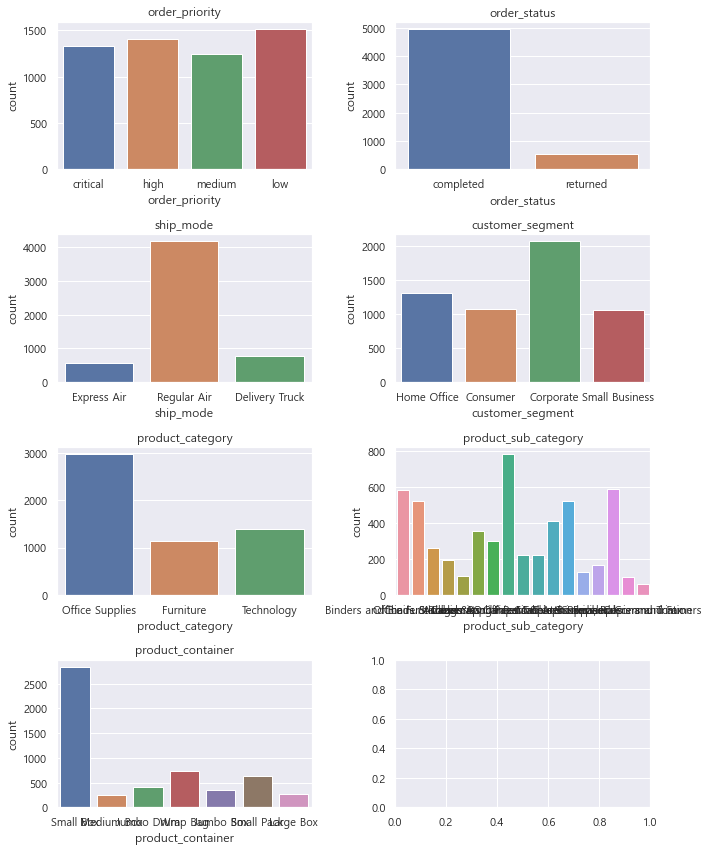

```python
figure, ax_list_list = plt.subplots(nrows=4, ncols=2);
figure.set_size_inches(10,12)

ax_list = ax_list_list.reshape(8)
print(ax_list_list.shape)
print(ax_list.shape)

for i in range(len(category_cols)):
    col = category_cols[i]
    sns.countplot(data=EW_df, x=col, ax=ax_list[i])
    ax_list[i].set_title(col)

plt.tight_layout();
```

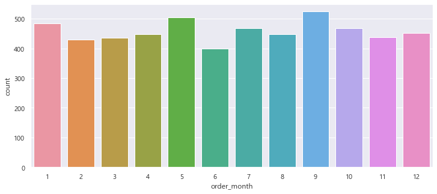

```python
plt.figure(figsize = (12,5))
sns.countplot(data=EW_df, x='order_month');
```

```
(6, 2)
(12,)
```

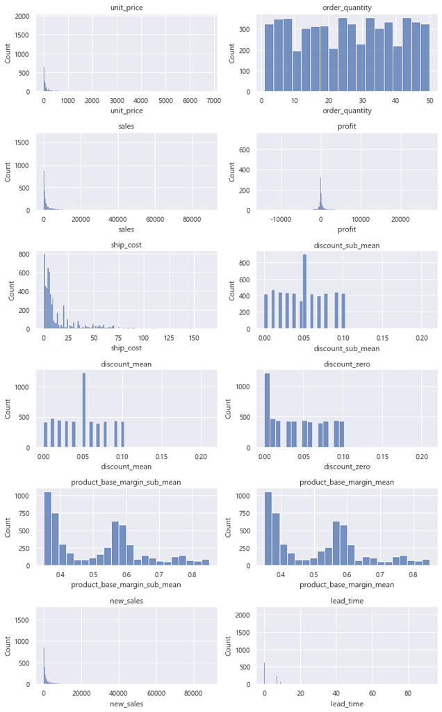

```python
#카테고리 컬럼별로 countplot 그려보기
figure, ax_list_list = plt.subplots(nrows=6, ncols=2);
figure.set_size_inches(10,16)

ax_list = ax_list_list.reshape(12)
print(ax_list_list.shape)
print(ax_list.shape)

for i in range(len(numerical_cols)):
    col = numerical_cols[i]
    sns.histplot(data=EW_df, x=col, ax=ax_list[i])
    ax_list[i].set_title(col)

plt.tight_layout();
```

## Correlation Matrix로 상관분석해보기

```python
EW_df[['unit_price', 'order_quantity', 'sales', 'profit', 'ship_cost', 'discount_sub_mean', 'product_base_margin_sub_mean', 'new_sales', 'lead_time']].corr()
```

|  | unit_price | order_quantity | sales | profit | ship_cost | discount_sub_mean | product_base_margin_sub_mean | new_sales | lead_time |
| --- | --- | --- | --- | --- | --- | --- | --- | --- | --- |
| unit_price | 1.000000 | -0.099357 | 0.635889 | 0.085621 | 0.239373 | 0.013137 | 0.053644 | 0.647253 | 0.005193 |
| order_quantity | -0.099357 | 1.000000 | 0.218600 | 0.193184 | -0.006395 | -0.008438 | 0.010576 | 0.219732 | 0.016272 |
| sales | 0.635889 | 0.218600 | 1.000000 | 0.628095 | 0.424441 | -0.021522 | 0.142033 | 0.996762 | 0.012319 |
| profit | 0.085621 | 0.193184 | 0.628095 | 1.000000 | -0.006664 | -0.034615 | -0.111309 | 0.620122 | 0.009785 |
| ship_cost | 0.239373 | -0.006395 | 0.424441 | -0.006664 | 1.000000 | -0.003586 | 0.363110 | 0.416252 | 0.003315 |
| discount_sub_mean | 0.013137 | -0.008438 | -0.021522 | -0.034615 | -0.003586 | 1.000000 | -0.009047 | -0.022652 | -0.010538 |
| product_base_margin_sub_mean | 0.053644 | 0.010576 | 0.142033 | -0.111309 | 0.363110 | -0.009047 | 1.000000 | 0.145491 | -0.012811 |
| new_sales | 0.647253 | 0.219732 | 0.996762 | 0.620122 | 0.416252 | -0.022652 | 0.145491 | 1.000000 | 0.013230 |
| lead_time | 0.005193 | 0.016272 | 0.012319 | 0.009785 | 0.003315 | -0.010538 | -0.012811 | 0.013230 | 1.000000 |

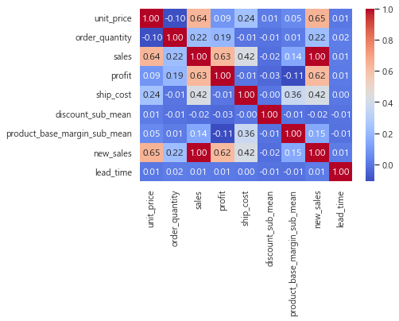

```python
g = sns.heatmap(EW_df[['unit_price', 'order_quantity', 'sales', 'profit', 'ship_cost', 'discount_sub_mean', 'product_base_margin_sub_mean', 'new_sales', 'lead_time']].corr(),
              annot = True,
              fmt = ".2f",
              cmap = "coolwarm")
```

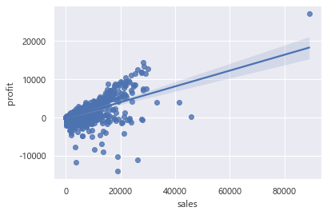

```python
sns.regplot(data=EW_df, x="sales", y="profit");
```

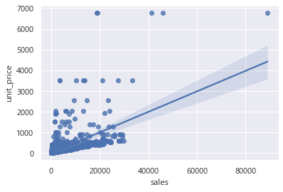

```python
sns.regplot(data=EW_df, x="sales", y="unit_price");
```

- `sales`와 `profit`이 높은 상관관계를 보이고 있습니다.
- `sales`와 `unit_price` 또한 높은 상관관계를 보이고 있습니다.
- 추가 생성한 변수 `new_sales`와 `sales`는 상관관계가 1로 기존 `sales`컬럼 그대로 사용합니다.

## 날짜별 분석

- `order_date`와 `ship_date`의 변수들 설펴봅니다.

```python
EW_df.query("order_year == 2015")
```

|  | record_id | order_id | order_date | order_priority | unit_price | order_quantity | sales | order_status | profit | ship_mode | ... | order_year | order_month | order_day | order_quarter | ship_yearmonth | ship_year | ship_month | ship_day | ship_quarter | lead_time |
| --- | --- | --- | --- | --- | --- | --- | --- | --- | --- | --- | --- | --- | --- | --- | --- | --- | --- | --- | --- | --- | --- |
| 2681 | 396 | 17861 | 2015-12-31 | critical | 95.99 | 9 | 872.4856 | returned | -342.9088 | Regular Air | ... | 2015 | 12 | 3 | 4 | 201601 | 2016 | 1 | 5 | 1 | 2 |
| 6391 | 3674 | 37420 | 2015-12-31 | high | 5.98 | 32 | 180.3656 | completed | -111.7988 | Regular Air | ... | 2015 | 12 | 3 | 4 | 201601 | 2016 | 1 | 4 | 1 | 1 |

2 rows × 38 columns

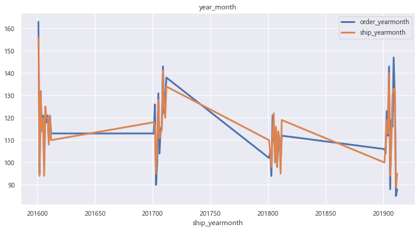

```python
plt.figure(figsize=(12,6));
EW_df.query("order_year > 2015").groupby("order_yearmonth").record_id.count().plot(kind = "line", linewidth = 3);
EW_df.groupby("ship_yearmonth").record_id.count().plot(kind = "line", linewidth = 3);
plt.xticks(rotation=0);
plt.legend(['order_yearmonth', 'ship_yearmonth'])
plt.title('year_month');
```

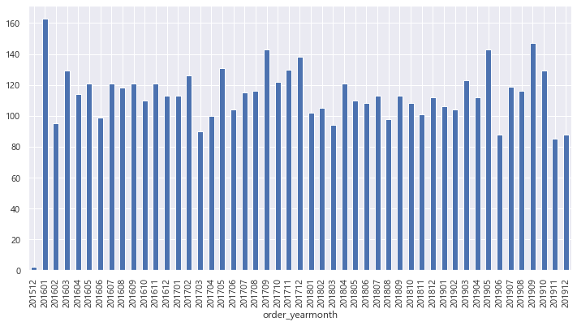

```python
EW_df.groupby('order_yearmonth').record_id.count().plot(figsize=(12,6), kind='bar');
```

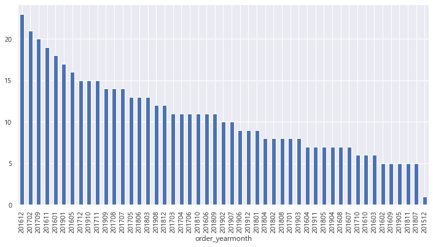

```python
EW_df.query("order_status == 'returned'").groupby('order_yearmonth').record_id.count().sort_values(ascending=False).plot(figsize=(12,6), kind='bar');
```

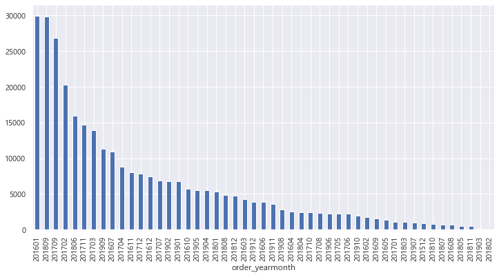

```python
EW_df.query("order_status == 'returned' & profit < 0").groupby('order_yearmonth').sales.sum().sort_values(ascending=False).plot(figsize=(12,6), kind='bar');
```

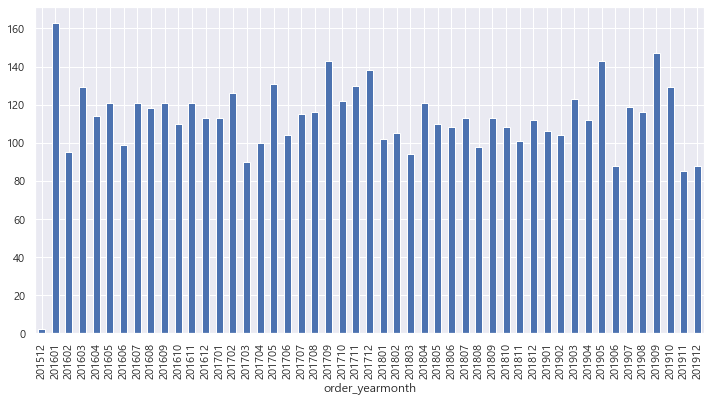

```python
EW_df.groupby('order_yearmonth').order_quantity.count().plot(figsize=(12,6), kind='bar');
```

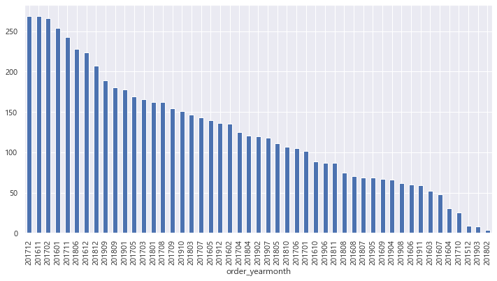

```python
EW_df.query("order_status == 'returned' & profit < 0").groupby('order_yearmonth').order_quantity.sum().sort_values(ascending=False).plot(figsize=(12,6), kind='bar');
```

- `order_date`와 `ship_date`는 거의 유사한 패턴을 보이고 있습니다.
- 주문 건수/수량에 비해 반품 건수/수량은 점차 낮아지는 추세를 보입니다.

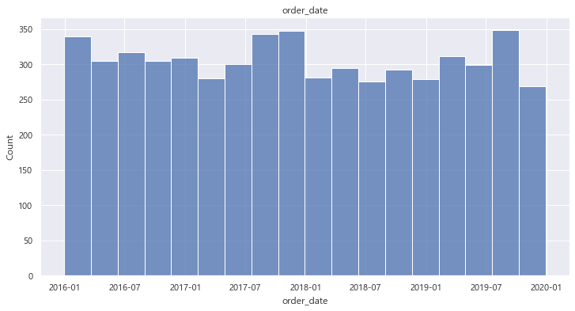

```python
plt.figure(figsize=(12,6))
sns.histplot(EW_df['order_date']);
plt.title('order_date')
plt.show()
```

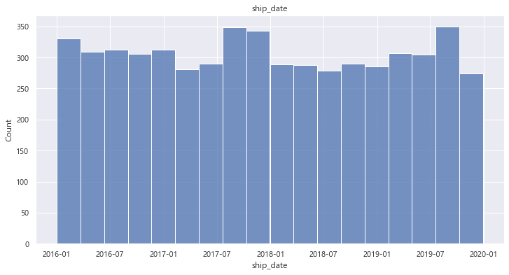

```python
plt.figure(figsize=(12,6))
sns.histplot(EW_df['ship_date']);
plt.title('ship_date')
plt.show()
```

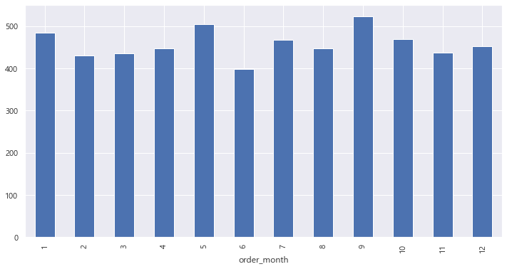

```python
EW_df.groupby('order_month').record_id.count().plot(figsize=(12,6), kind='bar');
```

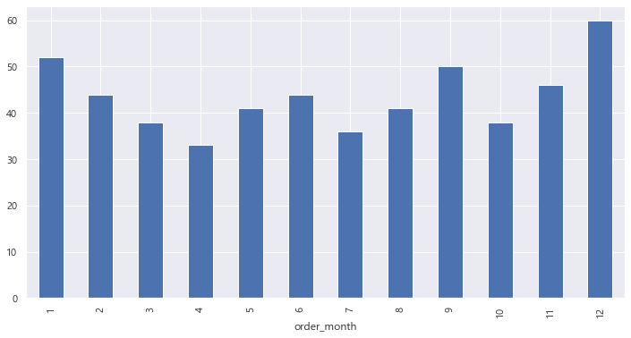

```python
EW_df.query("order_status == 'returned'").groupby('order_month')['order_id'].count().plot(figsize=(12,6), kind='bar');
```

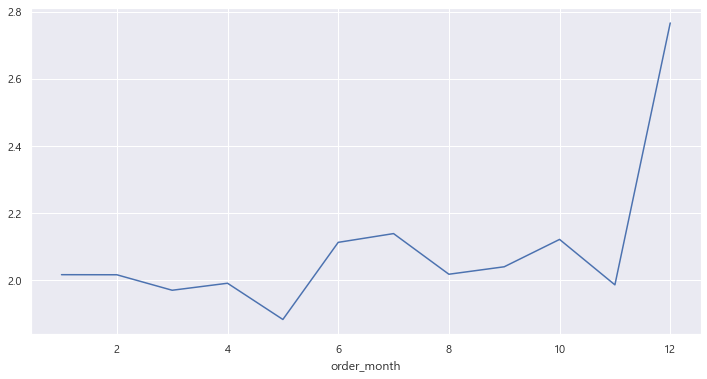

```python
EW_df.groupby('order_month').lead_time.mean().plot(figsize=(12,6), kind='line');
```

```python
EW_df.groupby(['product_sub_category', 'product_name', 'order_month']).lead_time.max().sort_values(ascending=False).iloc[:20]
```

```
product_sub_category          product_name                                                                         order_month
Pens & Art Supplies           Quartet Alpha White Chalk, 12/Pack                                                   12             92
Envelopes                     #10 Self-Seal White Envelopes                                                        12             84
Telephones and Communication  688                                                                                  12             31
                              282                                                                                  12             28
Pens & Art Supplies           Staples SlimLine Pencil Sharpener                                                    12             27
Telephones and Communication  Bell Sonecor JB700 Caller ID                                                         12             24
                              M3682                                                                                12             19
                              6000                                                                                 12             17
Chairs & Chairmats            Office Star - Contemporary Task Swivel chair with 2-way adjustable arms, Plum        12             17
Paper                         Xerox 220                                                                            12             15
Computer Peripherals          Logitech Cordless Elite Duo                                                          12             11
Paper                         Xerox 1908                                                                           12             11
Labels                        Avery 51                                                                             5               9
Appliances                    Conquest™ 14 Commercial Heavy-Duty Upright Vacuum, Collection System, Accessory Kit  10              9
Labels                        Avery 514                                                                            7               9
Storage & Organization        Letter Size Cart                                                                     4               9
Labels                        Avery 51                                                                             4               9
                              Self-Adhesive Address Labels for Typewriters by Universal                            2               9
Envelopes                     #10 Self-Seal White Envelopes                                                        5               9
Paper                         Xerox 1930                                                                           5               9
Name: lead_time, dtype: int64
```

- 반품이 가장 많은 달은 12월입니다.
- 12월에 주문일로부터 발송이 되기까지 리드타임이 약 2.8일로 가장 높게 나타났습니다.
- 리드타임이 제일 오래걸린 제품 카테고리를 살펴보니, Pens & Art Supplies, Envelopes, Telephones and Communication 순으로 높게 나타났습니다.
- 또한 서브 카테고리가 Telephones and Communication인 제품이 상위권을 차지하고 있는 것을 알 수 있습니다.
- 따라서, Telephones and Communication 제품의 리드타임이 반품에 영향을 끼칠 수 있어, 배송 방법 등을 개선해야 할 필요성이 있습니다.
- 5월과 9월이 주문량이 제일 많은 것으로 보입니다. 미국의 공휴일 일정과 관련이 있는 것으로 추측합니다. 따라서 관련한 캠페인을 진행하고 이익을 극대화하는 것이 좋겠습니다.

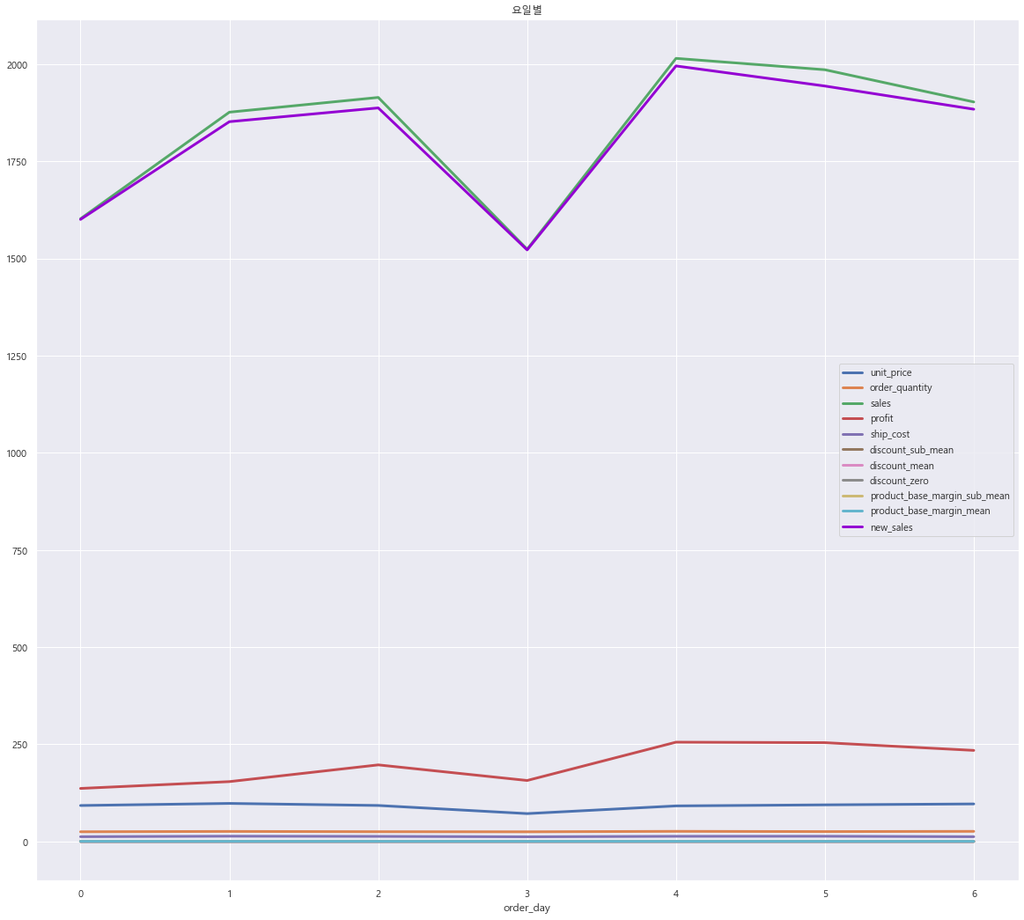

```python
plt.figure(figsize=(20,18));
EW_df.groupby("order_day").mean().unit_price.plot(kind = "line", linewidth = 3);
EW_df.groupby("order_day").mean().order_quantity.plot(kind = "line", linewidth = 3);
EW_df.groupby("order_day").mean().sales.plot(kind = "line", linewidth = 3);
EW_df.groupby("order_day").mean().profit.plot(kind = "line", linewidth = 3);
EW_df.groupby("order_day").mean().ship_cost.plot(kind = "line", linewidth = 3);
EW_df.groupby("order_day").mean().discount_sub_mean.plot(kind = "line", linewidth = 3);
EW_df.groupby("order_day").mean().discount_mean.plot(kind = "line", linewidth = 3);
EW_df.groupby("order_day").mean().discount_zero.plot(kind = "line", linewidth = 3);
EW_df.groupby("order_day").mean().product_base_margin_sub_mean.plot(kind = "line", linewidth = 3);
EW_df.groupby("order_day").mean().product_base_margin_mean.plot(kind = "line", linewidth = 3);
EW_df.groupby("order_day").mean().new_sales.plot(kind = "line", linewidth = 3,color='darkviolet');
plt.xticks(rotation=0);
plt.legend(['unit_price', 'order_quantity',"sales","profit","ship_cost","discount_sub_mean","discount_mean","discount_zero","product_base_margin_sub_mean","product_base_margin_mean","new_sales"])
plt.title('요일별');
```

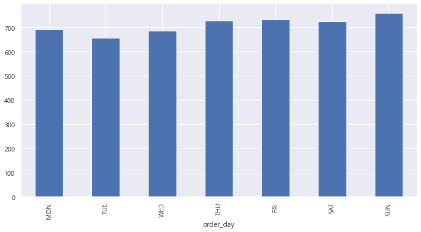

```python
EW_df.query("order_status == 'completed'").groupby('order_day').record_id.count().plot(figsize=(12,6), kind='bar')
plt.xticks(range(0,7), labels=['MON', 'TUE', 'WED', 'THU', 'FRI', 'SAT', 'SUN']);
```

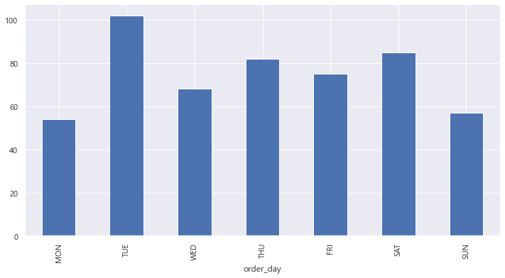

```python
EW_df.query("order_status == 'returned'").groupby('order_day')['order_id'].count().plot(figsize=(12,6), kind='bar')
plt.xticks(range(0,7), labels=['MON', 'TUE', 'WED', 'THU', 'FRI', 'SAT', 'SUN']);
```

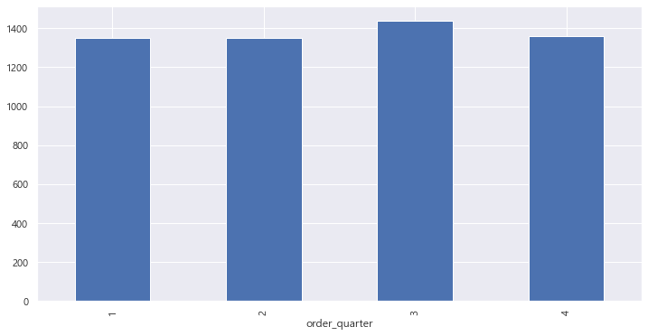

```python
EW_df.groupby('order_quarter').record_id.count().plot(figsize=(12,6), kind='bar');
```

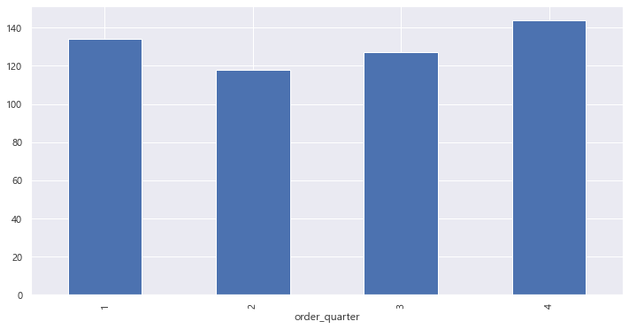

```python
EW_df.query("order_status == 'returned'").groupby('order_quarter')['order_id'].count().plot(figsize=(12,6), kind='bar');
```

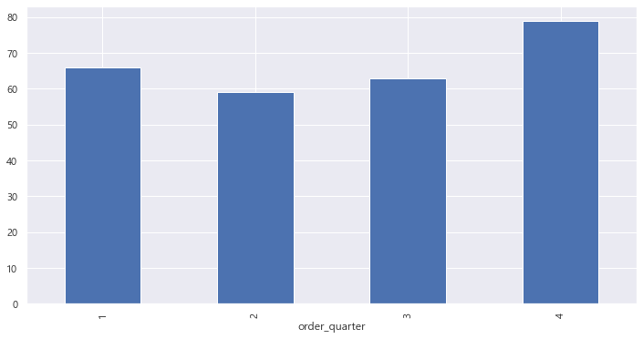

```python
EW_df.query("order_status == 'returned' & profit < 0").groupby('order_quarter')['order_id'].count().plot(figsize=(12,6), kind='bar');
```

## 제품 카테고리별 분석

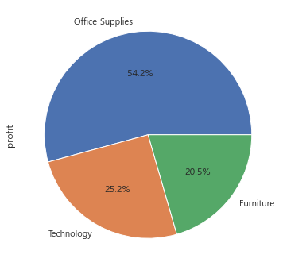

```python
EW_df.groupby(['product_category'])['profit'].count().sort_values(ascending=False).iloc[:10].plot(figsize=(12,6), kind='pie', autopct=('%1.1f%%'));
```

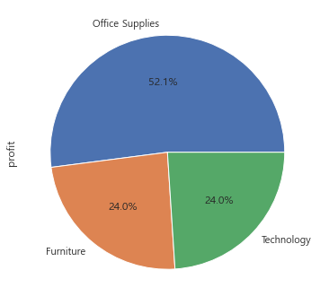

```python
EW_df.query("order_status == 'returned' & profit < 0").groupby(['product_category'])['profit'].count().sort_values(ascending=False).iloc[:10].plot(figsize=(12,6), kind='pie', autopct=('%1.1f%%'));
```

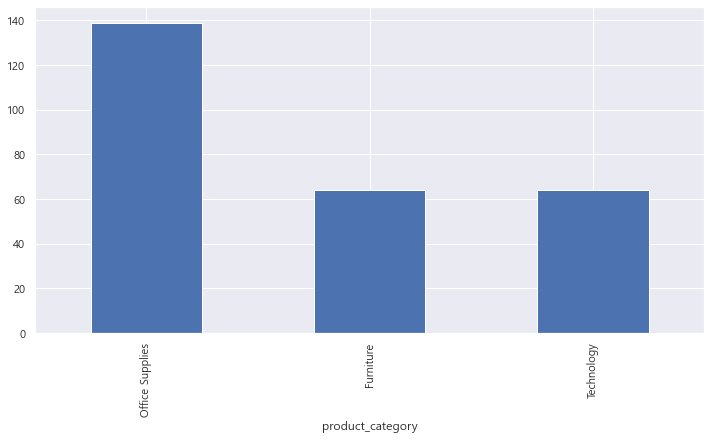

```python
EW_df.query("order_status == 'returned' & profit < 0").groupby(['product_category'])['profit'].count().sort_values(ascending=False).plot(figsize=(12,6), kind='bar');
```

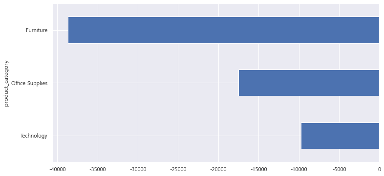

```python
EW_df.query("order_status == 'returned' & profit < 0").groupby(['product_category'])['profit'].sum().sort_values(ascending=False).plot(figsize=(12,6), kind='barh');
```

```python
EW_df.query("order_status == 'returned' & profit < 0").groupby(['product_category', 'product_sub_category', 'product_name'])['order_quantity'].sum().sort_values(ascending=False).iloc[:10]
```

```
product_category  product_sub_category          product_name
Technology        Computer Peripherals          Imation Neon Mac Format Diskettes, 10/Pack         136
Furniture         Bookcases                     Bush Mission Pointe Library                        118
                  Tables                        Bevis 36 x 72 Conference Tables                    114
Office Supplies   Pens & Art Supplies           Newell 342                                         111
Furniture         Bookcases                     O'Sullivan 3-Shelf Heavy-Duty Bookcases             90
Technology        Telephones and Communication  Bell Sonecor JB700 Caller ID                        87
Furniture         Office Furnishings            Eldon Expressions Mahogany Wood Desk Collection     87
Office Supplies   Storage & Organization        Tennsco Commercial Shelving                         76
Furniture         Bookcases                     O'Sullivan Elevations Bookcase, Cherry Finish       74
Office Supplies   Pens & Art Supplies           12 Colored Short Pencils                            73
Name: order_quantity, dtype: int64
```

```python
EW_df.query("order_status == 'returned' & profit < 0").groupby(['product_category', 'product_sub_category'])['profit'].sum().sort_values().iloc[:10]
```

```
product_category  product_sub_category
Furniture         Bookcases                        -19571.640800
                  Tables                           -13942.961379
Office Supplies   Storage & Organization            -9196.891200
Technology        Telephones and Communication      -5349.078200
Office Supplies   Paper                             -3493.239600
Furniture         Office Furnishings                -3308.284800
Technology        Computer Peripherals              -2085.047600
Furniture         Chairs & Chairmats                -1873.292800
Office Supplies   Appliances                        -1808.812800
                  Binders and Binder Accessories    -1617.184100
Name: profit, dtype: float64
```

```python
EW_df.query("order_status == 'returned' & profit < 0").groupby(['product_category', 'product_sub_category', 'product_name'])['profit'].sum().sort_values().iloc[:10]
```

```
product_category  product_sub_category    product_name
Furniture         Bookcases               Riverside Palais Royal Lawyers Bookcase, Royale Cherry Finish       -11053.5988
                                          Bush Mission Pointe Library                                          -3068.4052
Office Supplies   Storage & Organization  Tennsco Commercial Shelving                                          -2324.4676
Furniture         Tables                  Hon 61000 Series Interactive Training Tables                         -2284.1376
Office Supplies   Storage & Organization  Tennsco Lockers, Gray                                                -2206.5676
Furniture         Bookcases               O'Sullivan 3-Shelf Heavy-Duty Bookcases                              -1843.9664
                  Tables                  BoxOffice By Design Rectangular and Half-Moon Meeting Room Tables    -1679.9676
Office Supplies   Appliances              Hoover Portapower™ Portable Vacuum                                   -1605.7288
Furniture         Tables                  Riverside Furniture Stanwyck Manor Table Series                      -1536.0256
                                          Hon iLevel™ Computer Training Table                                  -1460.7688
Name: profit, dtype: float64
```

```python
EW_df.groupby('product_sub_category')['profit'].mean().sort_values()
```

```
product_sub_category
Tables                            -260.816009
Bookcases                          -75.702890
Scissors, Rulers and Trimmers      -56.459006
Rubber Bands                        -1.327732
Pens & Art Supplies                 14.773991
Storage & Organization              24.705916
Paper                               39.066353
Labels                              46.762703
Computer Peripherals               128.903146
Office Furnishings                 131.477670
Envelopes                          217.635801
Appliances                         266.194000
Binders and Binder Accessories     351.458996
Chairs & Chairmats                 357.888009
Telephones and Communication       361.285797
Office Machines                   1078.449617
Copiers and Fax                   2052.626814
Name: profit, dtype: float64
```

```python
EW_df.groupby('product_sub_category')['lead_time'].mean().sort_values()
```

```
product_sub_category
Scissors, Rulers and Trimmers     1.742268
Labels                            1.958549
Computer Peripherals              1.984586
Binders and Binder Accessories    1.986231
Chairs & Chairmats                1.988327
Office Furnishings                1.996176
Storage & Organization            1.997159
Rubber Bands                      2.009709
Paper                             2.065217
Appliances                        2.073333
Copiers and Fax                   2.140351
Pens & Art Supplies               2.148058
Tables                            2.158371
Office Machines                   2.166667
Telephones and Communication      2.286441
Bookcases                         2.359375
Envelopes                         2.619632
Name: lead_time, dtype: float64
```

```python
EW_df.groupby('product_sub_category')['discount_mean'].mean().sort_values()
```

```
product_sub_category
Scissors, Rulers and Trimmers     0.046561
Tables                            0.047458
Envelopes                         0.047498
Telephones and Communication      0.048053
Computer Peripherals              0.048316
Office Furnishings                0.048474
Rubber Bands                      0.048686
Copiers and Fax                   0.049574
Labels                            0.049643
Bookcases                         0.049933
Paper                             0.050196
Office Machines                   0.050494
Binders and Binder Accessories    0.050651
Storage & Organization            0.050955
Chairs & Chairmats                0.050999
Pens & Art Supplies               0.051333
Appliances                        0.052045
Name: discount_mean, dtype: float64
```

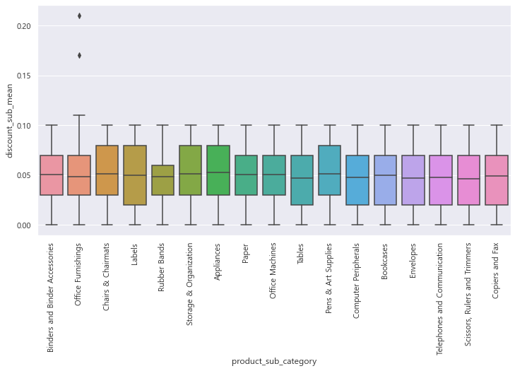

```python
plt.figure(figsize=(12,6))
sns.boxplot(data=EW_df, x='product_sub_category', y='discount_sub_mean')
plt.xticks(rotation=90)
plt.show()
```

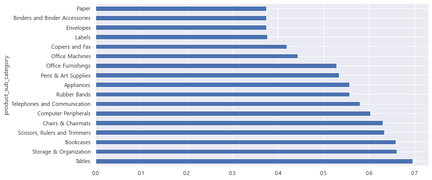

```python
EW_df.groupby('product_sub_category')['product_base_margin_sub_mean'].mean().sort_values(ascending=False).plot(figsize=(12,6), kind='barh');
```

```python
EW_df.groupby('product_sub_category')['unit_price'].mean().sort_values(ascending=False)
```

```
product_sub_category
Copiers and Fax                   720.165439
Office Machines                   575.248739
Tables                            221.247330
Chairs & Chairmats                185.760000
Bookcases                         185.384844
Telephones and Communication       98.842542
Storage & Organization             82.111932
Appliances                         78.136167
Binders and Binder Accessories     63.396695
Computer Peripherals               43.030231
Office Furnishings                 33.989025
Envelopes                          30.133067
Scissors, Rulers and Trimmers      25.149588
Paper                              14.399450
Pens & Art Supplies                 9.706820
Labels                              4.934145
Rubber Bands                        2.942718
Name: unit_price, dtype: float64
```

```python
EW_df.query("product_sub_category == 'Office Machines'").groupby(['product_sub_category','product_name', 'sales', 'order_quantity'])['profit'].sum().sort_values().iloc[:10]
```

```
product_sub_category  product_name                                           sales       order_quantity
Office Machines       Polycom ViewStation™ ISDN Videoconferencing Unit       18888.0056  3                -14140.7004
                                                                             19014.2456  4                -10263.6585
                      Okidata Pacemark 4410N Wide Format Dot Matrix Printer  10380.3456  3                 -8389.4697
                                                                             3501.7956   1                 -7838.3334
                                                                             13070.2056  4                 -6923.5980
                      Epson DFX-8500 Dot Matrix Printer                      9396.4156   4                 -4991.4237
                      Lexmark 4227 Plus Dot Matrix Printer                   5972.5956   3                 -4852.5282
                                                                             6041.0156   3                 -4793.0028
                                                                             1893.9356   1                 -4654.7337
                      Okidata Pacemark 4410N Wide Format Dot Matrix Printer  21134.7156  6                 -4266.0873
Name: profit, dtype: float64
```

## 고객군별 분석

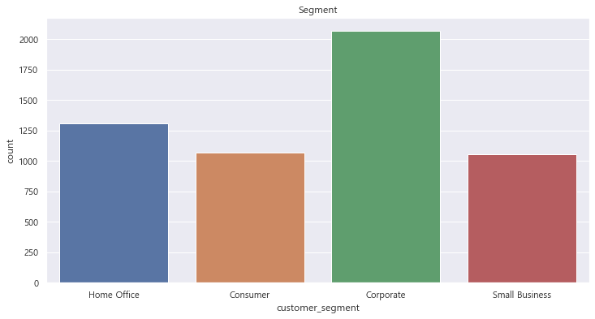

```python
plt.figure(figsize=(12,6))
sns.countplot(x=EW_df['customer_segment']);
plt.title('Segment')
plt.show()
```

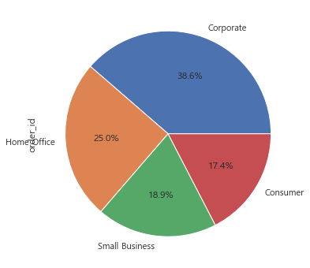

```python
EW_df.query("order_status == 'returned'").groupby('customer_segment')['order_id'].count().sort_values(ascending=False).plot(figsize=(12,6), kind='pie', autopct=('%1.1f%%'));
```

```python
EW_df.query("order_status == 'returned'").groupby(['customer_segment', 'product_sub_category'])['order_id'].count().sort_values(ascending=False)
```

```
customer_segment  product_sub_category
Corporate         Paper                             32
                  Telephones and Communication      23
                  Office Furnishings                21
                  Binders and Binder Accessories    20
                  Pens & Art Supplies               18
                                                    ..
Consumer          Tables                             1
                  Scissors, Rulers and Trimmers      1
Small Business    Scissors, Rulers and Trimmers      1
Consumer          Rubber Bands                       1
                  Appliances                         1
Name: order_id, Length: 65, dtype: int64
```

```python
EW_df.query("order_status == 'returned'").groupby(['customer_segment', 'product_sub_category'])['order_quantity'].sum().sort_values(ascending=False)
```

```
customer_segment  product_sub_category
Corporate         Paper                             813
                  Office Furnishings                569
                  Telephones and Communication      552
                  Binders and Binder Accessories    542
                  Pens & Art Supplies               515
                                                   ...
Consumer          Scissors, Rulers and Trimmers      34
Corporate         Copiers and Fax                    28
Small Business    Scissors, Rulers and Trimmers      22
Consumer          Appliances                         21
Small Business    Office Machines                    14
Name: order_quantity, Length: 65, dtype: int64
```

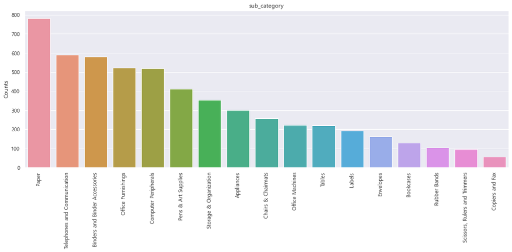

```python
item_counts = EW_df['product_sub_category'].value_counts().sort_values(ascending=False)
plt.figure(figsize=(18,6))
sns.barplot(item_counts.index, item_counts.values, palette=sns.set_palette("pastel"))
plt.ylabel("Counts")
plt.title("sub_category");
plt.xticks(rotation=90);
```

```python
EW_df.groupby(['product_category', 'product_sub_category']).record_id.count().sort_values(ascending=False).iloc[:20] / EW_df.record_id.count()*100
```

```
product_category  product_sub_category
Office Supplies   Paper                             14.218182
Technology        Telephones and Communication      10.727273
Office Supplies   Binders and Binder Accessories    10.563636
Furniture         Office Furnishings                 9.509091
Technology        Computer Peripherals               9.436364
Office Supplies   Pens & Art Supplies                7.490909
                  Storage & Organization             6.400000
                  Appliances                         5.454545
Furniture         Chairs & Chairmats                 4.672727
Technology        Office Machines                    4.036364
Furniture         Tables                             4.018182
Office Supplies   Labels                             3.509091
                  Envelopes                          2.963636
Furniture         Bookcases                          2.327273
Office Supplies   Rubber Bands                       1.872727
                  Scissors, Rulers and Trimmers      1.763636
Technology        Copiers and Fax                    1.036364
Name: record_id, dtype: float64
```

```python
EW_df.query("order_status == 'returned' & profit < 0").groupby('product_sub_category').profit.sum().sort_values()
```

```
product_sub_category
Bookcases                        -19571.640800
Tables                           -13942.961379
Storage & Organization            -9196.891200
Telephones and Communication      -5349.078200
Paper                             -3493.239600
Office Furnishings                -3308.284800
Computer Peripherals              -2085.047600
Chairs & Chairmats                -1873.292800
Appliances                        -1808.812800
Binders and Binder Accessories    -1617.184100
Copiers and Fax                   -1312.838800
Office Machines                   -1000.674300
Pens & Art Supplies                -973.797600
Envelopes                          -200.125200
Scissors, Rulers and Trimmers      -127.826400
Rubber Bands                        -65.540400
Labels                               -4.966400
Name: profit, dtype: float64
```

```python
EW_df.groupby('customer_segment').discount_sub_mean.mean().sort_values()
```

```
customer_segment
Home Office       0.048899
Small Business    0.049453
Corporate         0.049716
Consumer          0.050569
Name: discount_sub_mean, dtype: float64
```

```python
EW_df.groupby('customer_segment')['product_base_margin_sub_mean'].mean().sort_values()
```

```
customer_segment
Corporate         0.513519
Small Business    0.514910
Consumer          0.516498
Home Office       0.518956
Name: product_base_margin_sub_mean, dtype: float64
```

- 기업 고객에게서 반품율이 가장 높게 나타났으며, 그 중에서도 Paper 제품군에서 반품건수와 반품 수량이 제일 높게 나타남
- 또한, Paper 제품군의 경우 주문율이 약 14%로 가장 높으며, 반품액도 5번째로 높은 것을 알 수 있습니다.
- 기업의 경우 Paper을 필수불가결하게 많이 쓰게 됩니다. 따라서, 기업 고객을 대상으로 Paper 제품군의 할인을 진행하여 여러 제품을 한꺼번에 구매할 수 있도록 유도 할 수 있으며, 할인 이벤트 진행을 통해 저렴하게 구매하였다는 인식을 통해 반품률도 줄어든다면 수익성 개선에 도움될 것으로 보입니다.